# Lecture Lab 7

Leon Eyrich Jessen, Daniel Romero

2026

## The nightmare of keeping track of file versions

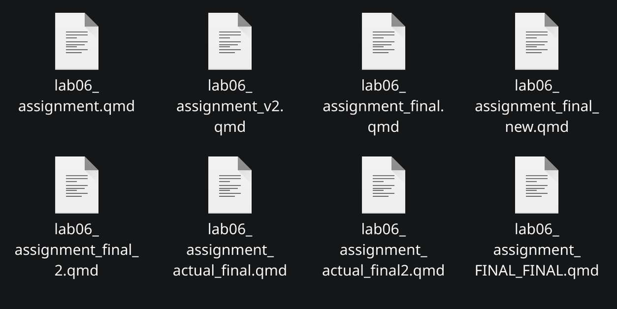

- How many of you have run into this situation…? Now imagine multiplying this by dozens of files in a common Bio Data Science project!
- This a is nightmare to work with and terrible for reproducibility!

## Version Control to the rescue

- To avoid situations like that, we use a *Version Control System* (VCS)
- i.e., a program that allows to store snapshots that we can go back to at any point in time
- `git` is by far the most popular Version Control tool for software projects in the world (>95% of all software projects)

[figure not shown]

## The git workflow

1. **Initialize** the git repository (only once per project)
2. Write and modify your code as usual
3. **Add** your changes to the staging area
4. Review the staging area
5. **Commit** your changes (save a version which you can return back to at any time)
6. Return to step 2

## The git workflow

1. **Initialize** the git repository (only once per project)
2. Write and modify your code as usual
3. **Add** your changes to the staging area
4. Review the staging area
5. **Commit** your changes (save a version which you can return back to at any time)
6. Return to step 2
- *Commit messages should be informative*
- *Ideally, every commit is a working version of the code*

## Centralized repositories

- The most common way to use `git` is pairing it with a *git repository hosting platform*
- i.e., a web service that will store your git repository and give you extra features on top of `git`

## Centralized repositories

- The most common way to use `git` is pairing it with a git repository hosting platform
- Web services that will store your git repository and give you extra features on top of `git`
- GitHub is the most popular, but there are many others:

[figure not shown]

- `git` and GitHub are related but completely different things! Think of it as R vs. RStudio

## Collaborative Bio Data Science using GitHub via RStudio

- When doing assignments, you discovered that it was challenging to collaborate
- Collaboration is key to success, **also** when coding!
- You could:
  - Write your code in a google doc and copy/paste
  - Send code snippets in emails
  - Use a whatsapp-group to exchange code
  - …?

## Collaborative Bio Data Science using GitHub via RStudio

- When doing assignments, you discovered that it was challenging to collaborate
- Collaboration is key to success, **also** when coding!
- You could:
  - Write your code in a google doc and copy/paste
  - Send code snippets in emails
  - Use a whatsapp-group to exchange code
  - Stare at the same screen and come with 17 suggestions
  - …?
- All of which would be a recipe for inevitable disaster!

## Okay, so… How does your team “do” it?

Github is not only a backup, but a collaboration platform

[figure not shown]

## Pulling and pushing!

When working with collaborators, we have to add a few extra step to the git workflow…

### Before

1. **Initialize** the git repository (only once per project)
2. Write and modify your code as usual
3. **Add** your changes to the staging area
4. Review the staging area
5. **Commit** your changes (save a version which you can return back to at any time)
6. Return to step 2

## Pulling and pushing!

When working with collaborators, we have to add a few extra step to the git workflow…

### After

1. **Initialize** the git repository (only once per project)
2. Write and modify your code as usual
3. **Add** your changes to the staging area
4. Review the staging area
5. **Commit** your changes (save a version which you can return back to at any time)
6. **Pull** new changes from the central repo
7. **Push** your changes to the central repo
8. Return to step 2

## Pulling and pushing!

When working with collaborators, we have to add a few extra step to the git workflow…

### After*

1. **Initialize** the git repository (only once per project)
2. Write and modify your code as usual
3. **Add** your changes to the staging area
4. Review the staging area
5. **Commit** your changes (save a version which you can return back to at any time)
6. **Pull** new changes from the central repo
7. [Occasionally] **Solve merge conflicts**
8. **Push** your changes to the central repo
9. Return to step 2

## Branching, a way of developing in parallel

With branches, you can work on your own without disturbing or getting disturbed by other people, then merge at the end.

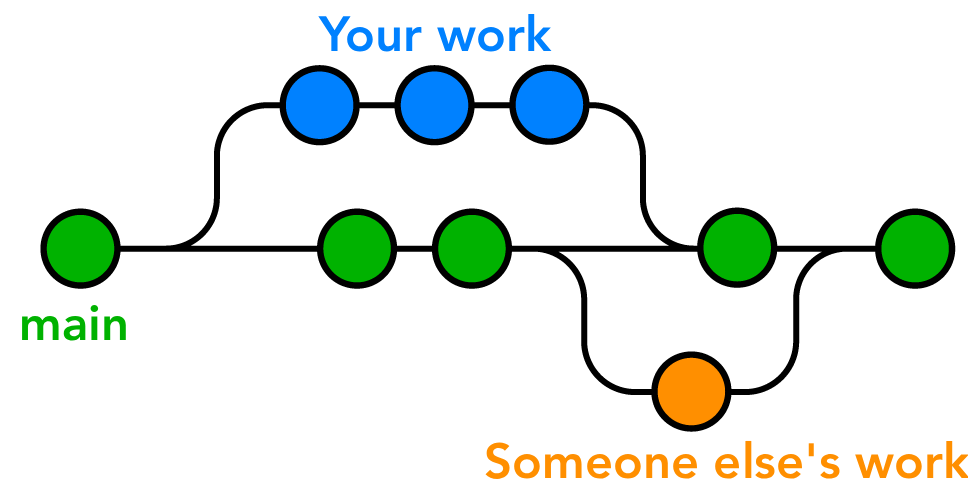

## Pull requests: contributing other people’s software

A feature of GitHub to contribute to other people’s code: work on your own independent branch, then request the maintainers that to pull your code into the main branch

[figure not shown]

## Final notes

- `git` is a powerful tool for reproducible data science
- We won’t do it today, but `git` is most powerful from the Terminal
- We will intentionally run you through the common issues with `git`. Don’t get discouraged!

## But really, the best thing is to…

- Try it out for your self
- **FOLLOWING TODAY’S EXERCISES POINT-BY-POINT IS SUPERCALIFRAGILISTICEXPIALIDOCIOUS!!!**
- Break and then exercises